# unit2_eda_tutorial

```python
import pandas as pd
import numpy as np
import matplotlib.pyplot as plt
import seaborn as sns
from scipy.stats import skew

from sklearn.compose import ColumnTransformer
from sklearn.preprocessing import OneHotEncoder
```

```python
data = pd.read_csv("auto-mpg.csv")
data.head()
```

|  | mpg | cylinders | displacement | horsepower | weight | acceleration | model year | origin | car name |
| --- | --- | --- | --- | --- | --- | --- | --- | --- | --- |
| 0 | 18.0 | 8 | 307.0 | 130 | 3504 | 12.0 | 70 | 1 | chevrolet chevelle malibu |
| 1 | 15.0 | 8 | 350.0 | 165 | 3693 | 11.5 | 70 | 1 | buick skylark 320 |
| 2 | 18.0 | 8 | 318.0 | 150 | 3436 | 11.0 | 70 | 1 | plymouth satellite |
| 3 | 16.0 | 8 | 304.0 | 150 | 3433 | 12.0 | 70 | 1 | amc rebel sst |
| 4 | 17.0 | 8 | 302.0 | 140 | 3449 | 10.5 | 70 | 1 | ford torino |

```python
data.tail()
```

|  | mpg | cylinders | displacement | horsepower | weight | acceleration | model year | origin | car name |
| --- | --- | --- | --- | --- | --- | --- | --- | --- | --- |
| 393 | 27.0 | 4 | 140.0 | 86 | 2790 | 15.6 | 82 | 1 | ford mustang gl |
| 394 | 44.0 | 4 | 97.0 | 52 | 2130 | 24.6 | 82 | 2 | vw pickup |
| 395 | 32.0 | 4 | 135.0 | 84 | 2295 | 11.6 | 82 | 1 | dodge rampage |
| 396 | 28.0 | 4 | 120.0 | 79 | 2625 | 18.6 | 82 | 1 | ford ranger |
| 397 | 31.0 | 4 | 119.0 | 82 | 2720 | 19.4 | 82 | 1 | chevy s-10 |

```python
data.describe()
```

|  | mpg | cylinders | displacement | weight | acceleration | model year | origin |
| --- | --- | --- | --- | --- | --- | --- | --- |
| count | 398.000000 | 398.000000 | 398.000000 | 398.000000 | 398.000000 | 398.000000 | 398.000000 |
| mean | 23.514573 | 5.454774 | 193.425879 | 2970.424623 | 15.568090 | 76.010050 | 1.572864 |
| std | 7.815984 | 1.701004 | 104.269838 | 846.841774 | 2.757689 | 3.697627 | 0.802055 |
| min | 9.000000 | 3.000000 | 68.000000 | 1613.000000 | 8.000000 | 70.000000 | 1.000000 |
| 25% | 17.500000 | 4.000000 | 104.250000 | 2223.750000 | 13.825000 | 73.000000 | 1.000000 |
| 50% | 23.000000 | 4.000000 | 148.500000 | 2803.500000 | 15.500000 | 76.000000 | 1.000000 |
| 75% | 29.000000 | 8.000000 | 262.000000 | 3608.000000 | 17.175000 | 79.000000 | 2.000000 |
| max | 46.600000 | 8.000000 | 455.000000 | 5140.000000 | 24.800000 | 82.000000 | 3.000000 |

*Create a dataframe of all the numerical features in the dataset. So grateful for this!!*

```python
num_features = data.select_dtypes(include=[np.number])
num_features.columns
```

```
Index(['mpg', 'cylinders', 'displacement', 'weight', 'acceleration',
       'model year', 'origin'],
      dtype='object')
```

## **1. Identify missing values in the dataset**

```python
# identify missing values using info()
data.info()
```

```
<class 'pandas.core.frame.DataFrame'>
RangeIndex: 398 entries, 0 to 397
Data columns (total 9 columns):
 #   Column        Non-Null Count  Dtype
---  ------        --------------  -----
 0   mpg           398 non-null    float64
 1   cylinders     398 non-null    int64
 2   displacement  398 non-null    float64
 3   horsepower    398 non-null    object
 4   weight        398 non-null    int64
 5   acceleration  398 non-null    float64
 6   model year    398 non-null    int64
 7   origin        398 non-null    int64
 8   car name      398 non-null    object
dtypes: float64(3), int64(4), object(2)
memory usage: 28.1+ KB
```

```python
# identify missing values using isnull() function
data.isnull()
```

|  | mpg | cylinders | displacement | horsepower | weight | acceleration | model year | origin | car name |
| --- | --- | --- | --- | --- | --- | --- | --- | --- | --- |
| 0 | False | False | False | False | False | False | False | False | False |
| 1 | False | False | False | False | False | False | False | False | False |
| 2 | False | False | False | False | False | False | False | False | False |
| 3 | False | False | False | False | False | False | False | False | False |
| 4 | False | False | False | False | False | False | False | False | False |
| ... | ... | ... | ... | ... | ... | ... | ... | ... | ... |
| 393 | False | False | False | False | False | False | False | False | False |
| 394 | False | False | False | False | False | False | False | False | False |
| 395 | False | False | False | False | False | False | False | False | False |
| 396 | False | False | False | False | False | False | False | False | False |
| 397 | False | False | False | False | False | False | False | False | False |

398 rows × 9 columns

*I prefer using the info() function because it provides a concise summary of the dataset, including the total number of rows and non-null values for each feature. From the output, we see that the dataset contains 398 rows, and all features have 398 non-null values. This is a clear indication that there are no missing values in the dataset, so no further analysis for missing data is necessary.*

## **2. Estimate Skewness and Kurtosis**

```python
num_features.skew()
```

```
mpg             0.457066
cylinders       0.526922
displacement    0.719645
weight          0.531063
acceleration    0.278777
model year      0.011535
origin          0.923776
dtype: float64
```

```python
num_features.kurtosis()
```

```
mpg            -0.510781
cylinders      -1.376662
displacement   -0.746597
weight         -0.785529
acceleration    0.419497
model year     -1.181232
origin         -0.817597
dtype: float64
```

*Positive Kurtosis indicates a peaked distribution and negative indicates a more flat distribution. Any kurtosis highger than 2 suggests a peaked distribution while a kurtosis below -2 indicates a too flat distribution (Hair et al., 2022)*

## **3. Replace categorical values with numerical values "One-hot Encoding"**

```python
# perform one hot encoding on feature "origin" to use in correlation heatmap

# columns to one-hot encode
cat_columns = ["origin"]

encoder = ColumnTransformer(
    transformers=[("onehot", OneHotEncoder(), cat_columns)], remainder="passthrough")

# transform
transformed = encoder.fit_transform(num_features)

# convert to dataframe
encoded_cols = encoder.named_transformers_["onehot"].get_feature_names_out(cat_columns)
all_columns = list(encoded_cols) + [col for col in num_features.columns if col not in cat_columns]
encoded_df = pd.DataFrame(transformed, columns=all_columns)
encoded_df.head()
```

|  | origin_1 | origin_2 | origin_3 | mpg | cylinders | displacement | weight | acceleration | model year |
| --- | --- | --- | --- | --- | --- | --- | --- | --- | --- |
| 0 | 1.0 | 0.0 | 0.0 | 18.0 | 8.0 | 307.0 | 3504.0 | 12.0 | 70.0 |
| 1 | 1.0 | 0.0 | 0.0 | 15.0 | 8.0 | 350.0 | 3693.0 | 11.5 | 70.0 |
| 2 | 1.0 | 0.0 | 0.0 | 18.0 | 8.0 | 318.0 | 3436.0 | 11.0 | 70.0 |
| 3 | 1.0 | 0.0 | 0.0 | 16.0 | 8.0 | 304.0 | 3433.0 | 12.0 | 70.0 |
| 4 | 1.0 | 0.0 | 0.0 | 17.0 | 8.0 | 302.0 | 3449.0 | 10.5 | 70.0 |

## **4. Correlation Heatmap**

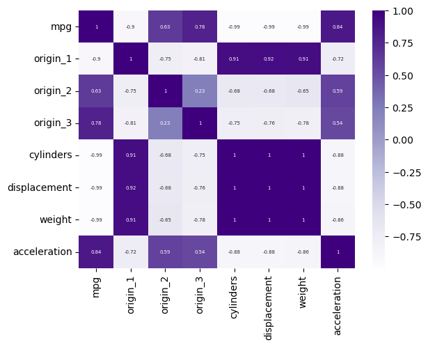

```python
selected_columns = ['mpg', 'origin_1', 'origin_2', 'origin_3', 'cylinders', 'displacement', 'weight', 'acceleration']
corr_matrix = encoded_df[selected_columns].corr()
dataplot = sns.heatmap(corr_matrix.corr(), cmap="Purples", annot=True, annot_kws={"fontsize":5}, vmax=1)
```

*mpg (miles per gallon) has a strong negative relationship to cylinders, displacement, weight and origin_1. The correlation between origin_1 and mpg has a strong negative relationship, suggesting that cars manufactured in this region tend to have a lower fuel efficiency compared to cars manufactured in origin_2 and 3*

*cylinders, displacement and weight are perfectly correlated to each other indicating multicollinearity among them.*

## **5. Scatter plots**

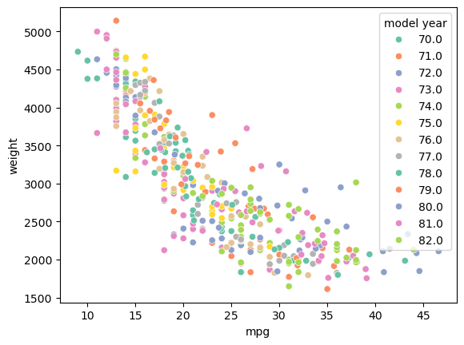

```python
sns.scatterplot(data = encoded_df,
                 x = 'mpg',
                 y = 'weight',
               hue = "model year",
               palette="Set2")
```

The above scatterplot illustrates the relationship between **weight** and **mpg** (miles per gallon). This shows a negative correlation  
between the two variables as we can also see from the correlation heatmap. As the vehicle weight increases, mpg decreases.

**model year** was included as the hue, the goal was to see if newer cars decreased in weight and mpg compared to older cars, but it seems that this is not the case in those years.

```python
data.groupby(['cylinders']).size()
```

```
cylinders
3      4
4    204
5      3
6     84
8    103
dtype: int64
```

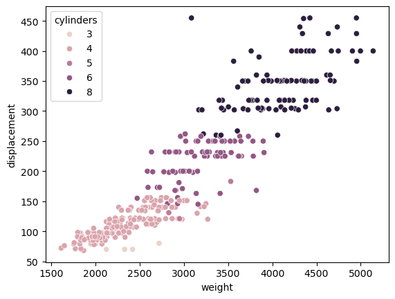

```python
sns.scatterplot(data = data,
                 x = 'weight',
                 y = 'displacement',
                 hue = 'cylinders')
```

*There is a strong positive correlation between **cylinders**, **displacement** & **weight** vehicles with higher displacement and/or cylinders increases the weight of a vehicle*

*This aligns with motor vehicle engineering norms, vehicles with larger engines (more displacement and cylinders are often designed to handle more weight to provide higher power*

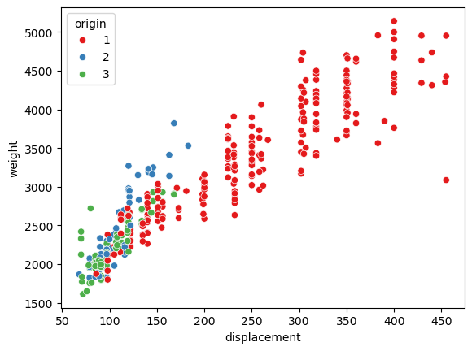

```python
sns.scatterplot(data = data,
                 x = 'displacement',
                 y = 'weight',
                hue = "origin",
               palette="Set1")
```

*Again we see a positive correlation between **weight** and **displacement**.* *This reflects trends in vehicle design in different regions.*

**Origin 1** tend to have larger displacements and heavier vehicles.  
**Origin 3** generally procudes lighter vehicles with smaller enginer displacements.  
**Origin 2** lies between origin 1 and origin 3

**References**

Hair, J. F., Hult, G. T. M., Ringle, C. M., & Sarstedt, M. (2022) *A Primer on Partial Least Squares Structural Equation Modeling (PLS-SEM)* 3rd ed. Thousand Oaks, CA: Sage Available from: https://www.smartpls.com/documentation/must-reads/pls-sem-book [Accessed 18 November 2024].